# Assignment; Introduction to Data Science

# Preamble

# Question 01

Consider “CPU_Performance.csv” dataset to answer the following questions.

## 1. Explore the given dataset and identify the attributes of CPU that have linear association with CPU performance.

### Import and inspect the dataset

The data set can be imported by using the `read.csv` function by specifying a relative path directory:

```r
cpu <- read.csv(file = "./Datasets/CPU.csv", header = TRUE, sep = ",")
head(cpu)
```

|  | CycleTime | MinimumMainMemory | MaximumMainMemory | CacheSize | MinimumNumberOfChannels | MaximumNumberOfChannels | Performance |
| --- | --- | --- | --- | --- | --- | --- | --- |
| 1 | 125 | 256 | 6000 | 256 | 16 | 128 | 198 |
| 2 | 29 | 8000 | 32000 | 32 | 8 | 32 | 269 |
| 3 | 29 | 8000 | 32000 | 32 | 8 | 32 | 220 |
| 4 | 29 | 8000 | 32000 | 32 | 8 | 32 | 172 |
| 5 | 29 | 8000 | 16000 | 32 | 8 | 16 | 132 |
| 6 | 26 | 8000 | 32000 | 64 | 8 | 32 | 318 |

Now inspect the structure, dimensions and summary of the dataset:

```r
summary(cpu)
```

```
   CycleTime      MinimumMainMemory MaximumMainMemory   CacheSize      MinimumNumberOfChannels MaximumNumberOfChannels  Performance
 Min.   :  17.0   Min.   :   64     Min.   :   64     Min.   :  0.00   Min.   : 0.000          Min.   :  0.00          Min.   :   6.0
 1st Qu.:  50.0   1st Qu.:  768     1st Qu.: 4000     1st Qu.:  0.00   1st Qu.: 1.000          1st Qu.:  5.00          1st Qu.:  27.0
 Median : 110.0   Median : 2000     Median : 8000     Median :  8.00   Median : 2.000          Median :  8.00          Median :  50.0
 Mean   : 203.8   Mean   : 2868     Mean   :11796     Mean   : 25.21   Mean   : 4.699          Mean   : 18.27          Mean   : 105.6
 3rd Qu.: 225.0   3rd Qu.: 4000     3rd Qu.:16000     3rd Qu.: 32.00   3rd Qu.: 6.000          3rd Qu.: 24.00          3rd Qu.: 113.0
 Max.   :1500.0   Max.   :32000     Max.   :64000     Max.   :256.00   Max.   :52.000          Max.   :176.00          Max.   :1150.0
```

```r
str(cpu)
```

```
'data.frame':   209 obs. of  7 variables:
 $ CycleTime              : int  125 29 29 29 29 26 23 23 23 23 ...
 $ MinimumMainMemory      : int  256 8000 8000 8000 8000 8000 16000 16000 16000 32000 ...
 $ MaximumMainMemory      : int  6000 32000 32000 32000 16000 32000 32000 32000 64000 64000 ...
 $ CacheSize              : int  256 32 32 32 32 64 64 64 64 128 ...
 $ MinimumNumberOfChannels: int  16 8 8 8 8 8 16 16 16 32 ...
 $ MaximumNumberOfChannels: int  128 32 32 32 16 32 32 32 32 64 ...
 $ Performance            : int  198 269 220 172 132 318 367 489 636 1144 ...
```

```r
dim(cpu)
```

```
[1] 209   7
```

From this we can see that there are 6 predictors for the performance of cpu

### Consider Correlation

in order to determine which ones have a linear association, take various correlation plots:

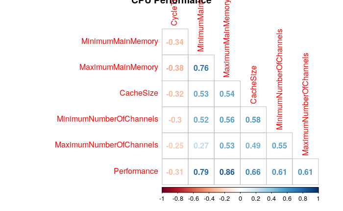

```r
corrplot(corr = cor(cpu), method = "number", type = "lower", title = "CPU Performance", diag = FALSE)
```

From this plot it can be seen that:

- Minimum Main Memory
- Maximum Main Memory

Are strongly postively correlated with CPU Performance, while:

- Cache Size
- Minimum Channels
- Maximum Channels

Are weakly correlated with CPU performance.

CPU Cycle time is weakly negatively correlated with performance and may not be useful predictor of performance.

However we may elect to include cycle time because from a theoretical perspective cycle time should be predictive of CPU performance, the weak correlation is likely more indicative of the performance measure than the actual capacity of the CPU, perhaps, for example this method may benefit unduely from memory rather than from raw speed.

### MultiColinearity

The minimum and maximum amount of memory appears to be strongly positively correlated, indicating that it may be appropriate to consider interaction of these two variables.

### Linearity

Although the pearson correlation Coefficient measures the strength of the linear relationship between variables, the data may have a non-linear tendency that may compromise the model’s capacity to forecast, hence we will consider the overall scatterplots to visually consider assumptions of homoskedasticity and linearity:

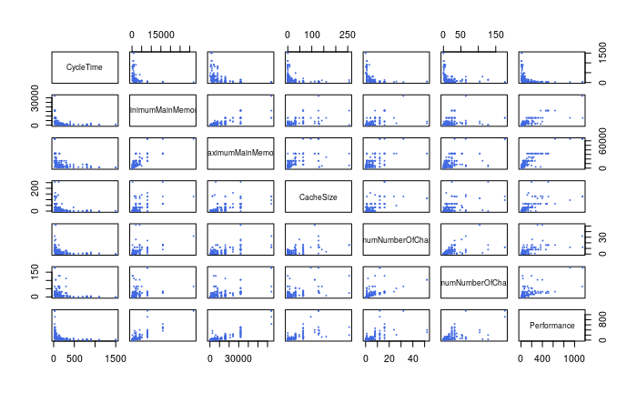

```r
pairs(cpu, cex = 0.05, col = "RoyalBlue")
```

This clearly demonstrates that the Number of channels has a non-constant variance with respect to performance and that the cycle time has a non-linear relationship, probably hyperbolic or quadratic.

It would violate assumptions taken in linear regression to use this variable in linear regression and it would be hence innapropriate to include it.

So instead we will consider the inverse of Cycle Time in order to get a linear model:

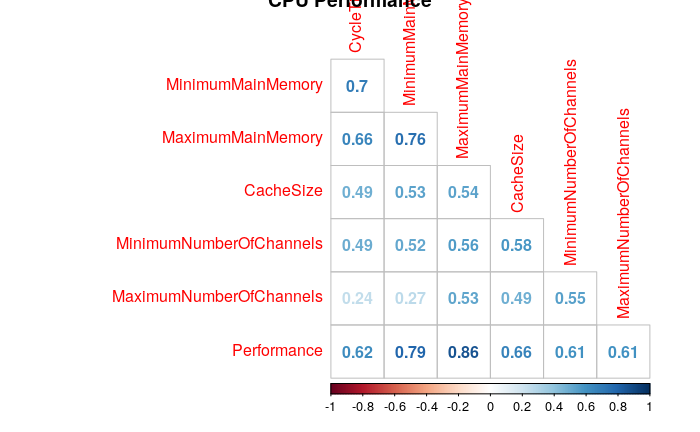

```r
cpu_invCyc <- cpu
cpu_invCyc$CycleTime <- cpu$CycleTime^-1
names(cpu_invCyc)[1] <- "CycleTimeInv"

corrplot(corr = cor(cpu_invCyc), method = "number", type = "lower", title = "CPU Performance", diag = FALSE)
```

Assuming this type of a relationship now makes cycle time a weakly correlated positive predictor.

## 2. Select the most suitable attribute of CPU that can be used to predict accurately the performance of CPU using Simple Linear Regression. Justify your choice of the attribute.

All attributes seem to be correlated with performance, however Maximum and Minimum performance seem to be correlated with each other and it may hence be in appropriate (overparameterisation) to include both these variables in the model (perhaps minimum memory drives maximum memory which in turn drives performance?)

Moreover CycleTime^-1 is correlated with minimum memory more highly than it is correlated with performance, so again it may be inappropriate to include cycletime^-1 and Main memory, perhaps e.g. lower higher cycletime^-1 means more memory is required and only the memory improves performance?

We will reject assumptions of significant multicolinearity for $\rho$ values of $\approx$ 0.5, this could be a result of both variables being correlated with performance, however the stron corelation previously mentioned needs to be considered.

### multiColinearity

Multicollinearity increases the standard errors of the coefficients. Increased standard errors in turn means that coefficients for some independent variables may be found not to be significantly different from 0. In other words, by overinflating the standard errors, multicollinearity makes some variables statistically insignificant when they should be significant. Without multicollinearity (and thus, with lower standard errors), those coefficients might be significant. [^1]

In order to deal with this we will fit a greedy model with all predictors and then use backwards selection to remove variables that are correlated with each other, if the R^2 and RMSE is not significantly compromised by this, the variables will be kept out of the model.

```r
cpu.lm_greedy <- lm(Performance ~ ., data = cpu_invCyc)
summary(cpu.lm_greedy)
```

```
Call:
lm(formula = Performance ~ ., data = cpu_invCyc)

Residuals:
    Min      1Q  Median      3Q     Max
-190.61  -25.49    8.49   26.16  398.02

Coefficients:
                          Estimate Std. Error t value Pr(>|t|)
(Intercept)             -3.913e+01  6.753e+00  -5.795 2.59e-08 ***
CycleTimeInv            -3.005e+02  5.197e+02  -0.578    0.564
MinimumMainMemory        1.537e-02  1.942e-03   7.917 1.58e-13 ***
MaximumMainMemory        5.450e-03  6.734e-04   8.094 5.34e-14 ***
CacheSize                6.141e-01  1.426e-01   4.307 2.58e-05 ***
MinimumNumberOfChannels -3.032e-01  8.808e-01  -0.344    0.731
MaximumNumberOfChannels  1.445e+00  2.275e-01   6.351 1.39e-09 ***
---
Signif. codes:  0 ‘***’ 0.001 ‘**’ 0.01 ‘*’ 0.05 ‘.’ 0.1 ‘ ’ 1

Residual standard error: 61.09 on 202 degrees of freedom
Multiple R-squared:  0.8599,    Adjusted R-squared:  0.8557
F-statistic: 206.6 on 6 and 202 DF,  p-value: < 2.2e-16
```

```r
AIC(cpu.lm_greedy)
```

```
[1] 2320.927
```

```r
BIC(cpu.lm_greedy)
```

```
[1] 2347.665
```

As anticipated CycleTime^-1 is non-significant and so is the number of channels, using backward substitution and removing these variables gives the model:

(be mindfuld that we could have used forward selection and removed other variables instead, we would have gotten a similar but slightly different model)

```r
cpu.lm_cleaned <- lm(Performance ~ . -CycleTimeInv -MinimumNumberOfChannels, data = cpu_invCyc)
summary(cpu.lm_cleaned)
```

```
Call:
lm(formula = Performance ~ . - CycleTimeInv - MinimumNumberOfChannels,
    data = cpu_invCyc)

Residuals:
    Min      1Q  Median      3Q     Max
-186.73  -26.08    8.27   26.99  402.87

Coefficients:
                          Estimate Std. Error t value Pr(>|t|)
(Intercept)             -40.982864   6.041898  -6.783 1.25e-10 ***
MinimumMainMemory         0.014887   0.001815   8.202 2.61e-14 ***
MaximumMainMemory         0.005330   0.000645   8.263 1.79e-14 ***
CacheSize                 0.587097   0.135764   4.324 2.39e-05 ***
MaximumNumberOfChannels   1.436179   0.210954   6.808 1.08e-10 ***
---
Signif. codes:  0 ‘***’ 0.001 ‘**’ 0.01 ‘*’ 0.05 ‘.’ 0.1 ‘ ’ 1

Residual standard error: 60.86 on 204 degrees of freedom
Multiple R-squared:  0.8595,    Adjusted R-squared:  0.8568
F-statistic: 312.1 on 4 and 204 DF,  p-value: < 2.2e-16
```

```r
AIC(cpu.lm_cleaned)
```

```
[1] 2317.471
```

```r
BIC(cpu.lm_cleaned)
```

```
[1] 2337.525
```

Removing these variable did not significantly affect the R^2 value (as in the amount of variation explained by the model) or the RMSE, a measurement of the misclassification of the model.

However Maximum Main Memory is still in this model and it is significant, so for this reason it will remain in the model.

It somewhat reduced the BIC and AIC, further evidence to accept this model

This will prevent over parameterisation and will prevent our model from having too much variance, it will increase model bias but this would be appropriate.

## 3. Model the performance of CPU using the attributes in the dataset, obtain the optimal model and Interpret your findings.

The model suggests that the following variables are highly significant owing to a very low p-value:

- Minimum Main Memory
- Maximum Main Memory
- Cache Size
- Maximimum Number of Channels

These variables are all positively associated with cpu performance. i

That is to say, these variables may be included in the model with a very low probability of incorrectly rejecting the hypothesis that there is no relationship between the variables, be careful this is not evidence that this model, or even a linear model is appropriate, merely that there isnt not a relationship between the variables, more over, some of these predictors were not homoskedastic and hence these p-values may not be indicative.

## 4. Carry out model diagnostics and comment your findings.

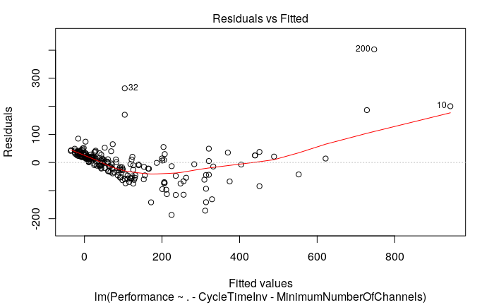

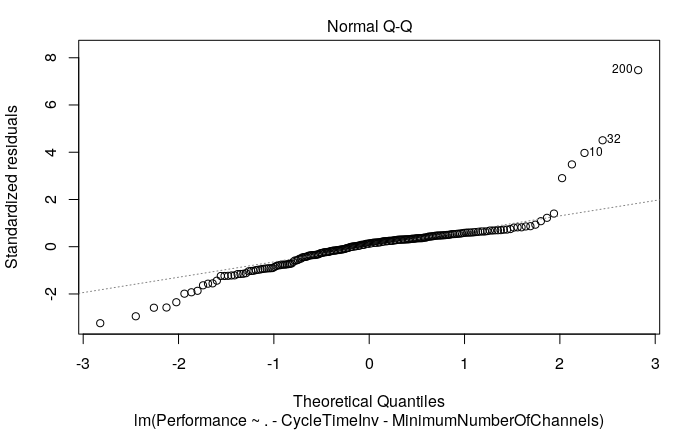

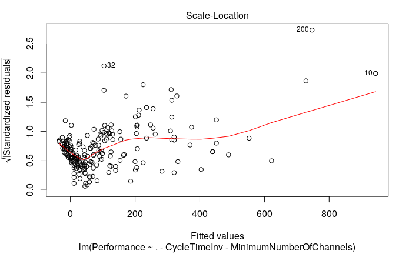

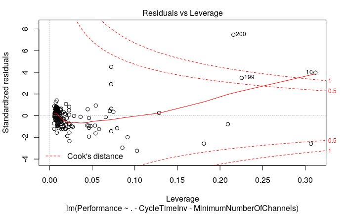

```r
plot(cpu.lm_cleaned)
```

these residuals are non-normal, in conjuction with the right-skewed histograms we may consider a log-transformation of the predictors, however our data has zeroes in it so instead wil will use a sqrt transform on the predictors.

Because the variance of the data increases over the fitted values a log-transform may be appropriate, although we may consider using a sqrt transform in order to use the same transform across variables.

because the variance is non-constant we will consider a concave transform of the predictors e.g. sqrt(y) or log (y), we have zeroes in the predictors so we choose root-transform of the response (Y).

## 5. Suggest an appropriate transformation to overcome the issues in the previous method.

Transforming data is a contentious issue [^2]

and should be applied with caution, for example consider using the RSS method on $\log (Y) = A \log(x) + B$ this will work, sure but it won’t work as well as a numerical solution for $y = b\cdot e^{ax}$, it’s only, empircally, 90 % as accurate.

for one it appears that the cpu performance is not normally distributed but log-normal, hence we will fit that in the model.

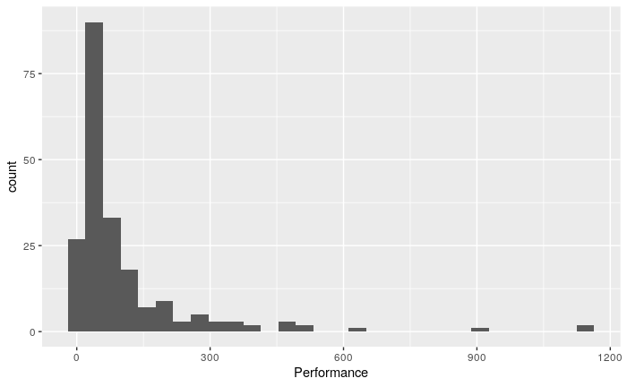

```r
ggplot(data = cpu, aes(x = Performance)) +
  geom_histogram()
```

Let’s go one further and consider the distribution of every variable:

```r
cpu.melt <- melt(data = cpu)
#cpu.melt$value <- sqrt(cpu.melt$value)
head(cpu.melt)
```

|  | variable | value |
| --- | --- | --- |
| 1 | CycleTime | 125 |
| 2 | CycleTime | 29 |
| 3 | CycleTime | 29 |
| 4 | CycleTime | 29 |
| 5 | CycleTime | 29 |
| 6 | CycleTime | 26 |

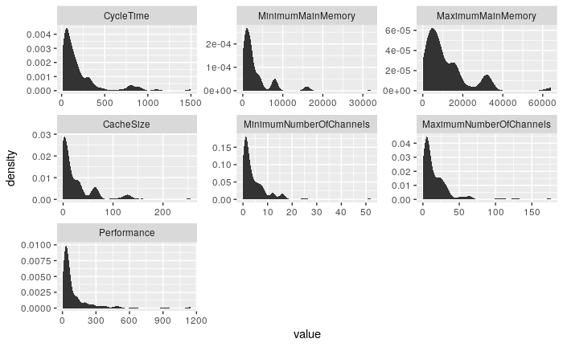

```r
ggplot(data = cpu.melt, aes(x = value)) +
stat_density() +
facet_wrap(~variable, scales = "free")
```

all these distributions are right-skewed, so we consider a log-normal distribution

We should consider a log-normal distribution when he residual’s standard deviation is proportional to your fitted values which we can see from our residual diagnostics above [^3]

[Some Info on Skewed Right Dist](https://www.itl.nist.gov/div898/handbook/eda/section3/histogr6.htm)

[Info on DistTypes](https://onlinelibrary.wiley.com/doi/pdf/10.1002/9781119197096.app03)

Although the sqrt will not be a powerful enough transformation for this, which can be seen from the histograms which I’ll generate later.

This leaves us with two choises:

- take log(x+1)
- Perform a box-cox transform
  - This is suitable here because none of the data is negative [^4]

### use sqrt transformation

```r
cpu_sqrt <- sqrt(cpu)
cpu.melt <- melt(data = cpu_sqrt)
#cpu.melt$value <- sqrt(cpu.melt$value)
head(cpu.melt)
```

|  | variable | value |
| --- | --- | --- |
| 1 | CycleTime | 11.180340 |
| 2 | CycleTime | 5.385165 |
| 3 | CycleTime | 5.385165 |
| 4 | CycleTime | 5.385165 |
| 5 | CycleTime | 5.385165 |
| 6 | CycleTime | 5.099020 |

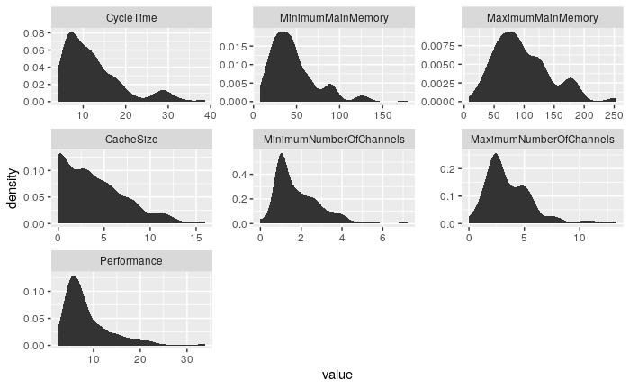

```r
ggplot(data = cpu.melt, aes(x = value)) +
stat_density() +
facet_wrap(~variable, scales = "free")
```

cache size still looks rediculous, let’s look at the pairs again:

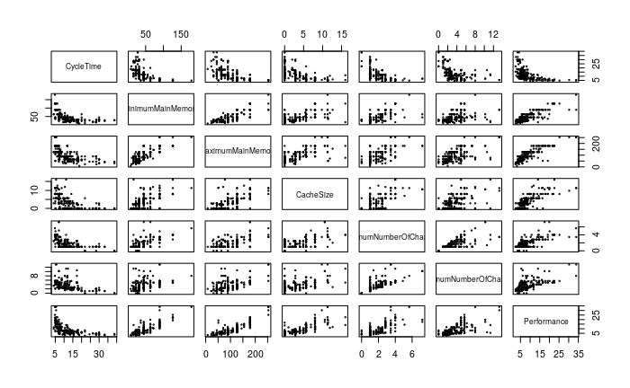

```r
pairs(cpu_sqrt, cex = 0.3)
```

The sqrt transform simply isn’t a strong enough transformation, let’s instead make a log-transform by using a $log(x+1)$ transform:

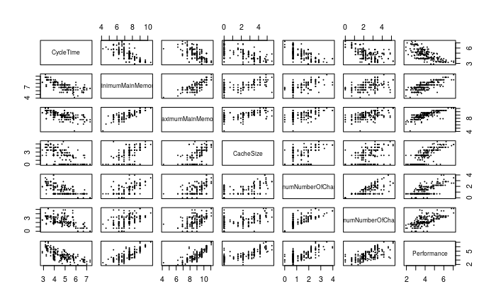

```r
pairs(log(cpu+1), cex = 0.2)
```

```r
cpu_log <- log(cpu+1)
cpu_log
```

| CycleTime | MinimumMainMemory | MaximumMainMemory | CacheSize | MinimumNumberOfChannels | MaximumNumberOfChannels | Performance |
| --- | --- | --- | --- | --- | --- | --- |
| 4.836282 | 5.549076 | 8.699681 | 5.5490761 | 2.8332133 | 4.8598124 | 5.293305 |
| 3.401197 | 8.987322 | 10.373522 | 3.4965076 | 2.1972246 | 3.4965076 | 5.598422 |
| 3.401197 | 8.987322 | 10.373522 | 3.4965076 | 2.1972246 | 3.4965076 | 5.398163 |
| 3.401197 | 8.987322 | 10.373522 | 3.4965076 | 2.1972246 | 3.4965076 | 5.153292 |
| 3.401197 | 8.987322 | 9.680406 | 3.4965076 | 2.1972246 | 2.8332133 | 4.890349 |
| 3.295837 | 8.987322 | 10.373522 | 4.1743873 | 2.1972246 | 3.4965076 | 5.765191 |
| 3.178054 | 9.680406 | 10.373522 | 4.1743873 | 2.8332133 | 3.4965076 | 5.908083 |
| 3.178054 | 9.680406 | 10.373522 | 4.1743873 | 2.8332133 | 3.4965076 | 6.194405 |
| 3.178054 | 9.680406 | 11.066654 | 4.1743873 | 2.8332133 | 3.4965076 | 6.456770 |
| 3.178054 | 10.373522 | 11.066654 | 4.8598124 | 3.4965076 | 4.1743873 | 7.043160 |

[output cut: 199 more lines]

```r
cpu.loglm <- lm(formula = Performance ~ ., data = cpu_log )
summary(cpu.loglm)
```

```
Call:
lm(formula = Performance ~ ., data = cpu_log)

Residuals:
     Min       1Q   Median       3Q      Max
-1.35971 -0.29745 -0.00534  0.24631  1.36089

Coefficients:
                         Estimate Std. Error t value Pr(>|t|)
(Intercept)             -1.172668   0.537896  -2.180  0.03041 *
CycleTime                0.008789   0.047821   0.184  0.85437
MinimumMainMemory        0.193738   0.048014   4.035 7.74e-05 ***
MaximumMainMemory        0.314581   0.046800   6.722 1.80e-10 ***
CacheSize                0.186244   0.024541   7.589 1.16e-12 ***
MinimumNumberOfChannels  0.196669   0.059242   3.320  0.00107 **
MaximumNumberOfChannels  0.128358   0.043766   2.933  0.00375 **
---
Signif. codes:  0 ‘***’ 0.001 ‘**’ 0.01 ‘*’ 0.05 ‘.’ 0.1 ‘ ’ 1

Residual standard error: 0.4311 on 202 degrees of freedom
Multiple R-squared:  0.8289,    Adjusted R-squared:  0.8238
F-statistic: 163.1 on 6 and 202 DF,  p-value: < 2.2e-16
```

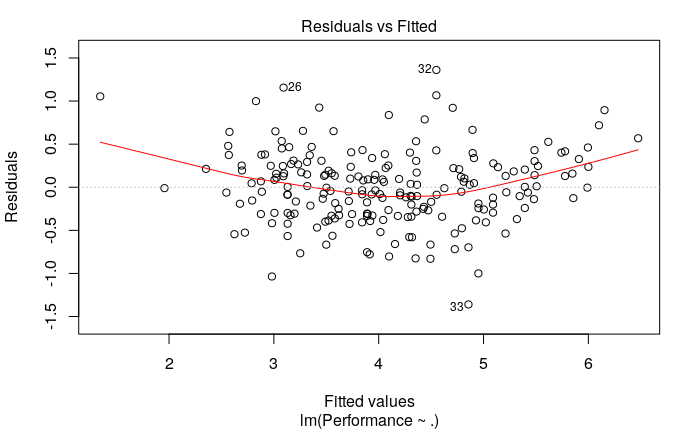

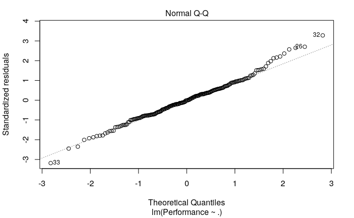

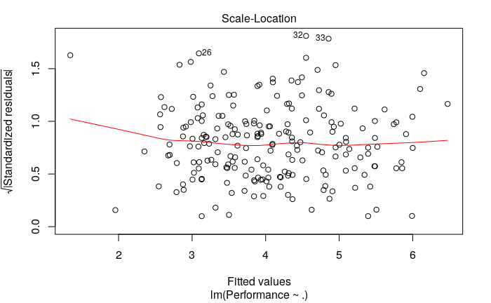

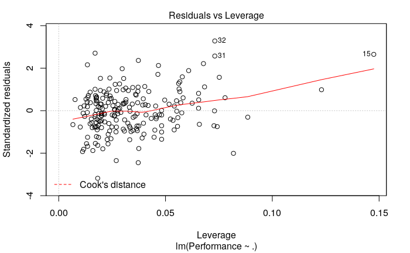

```r
plot(cpu.loglm)
```

```r
AIC(cpu.loglm)
```

```
[1] 250.2634
```

```r
BIC(cpu.loglm)
```

```
[1] 277.0021
```

So in this has resulted in the average Residual being $e^{0.43}$ and an AIC of 250, but let’s consider just log transforming the performance:

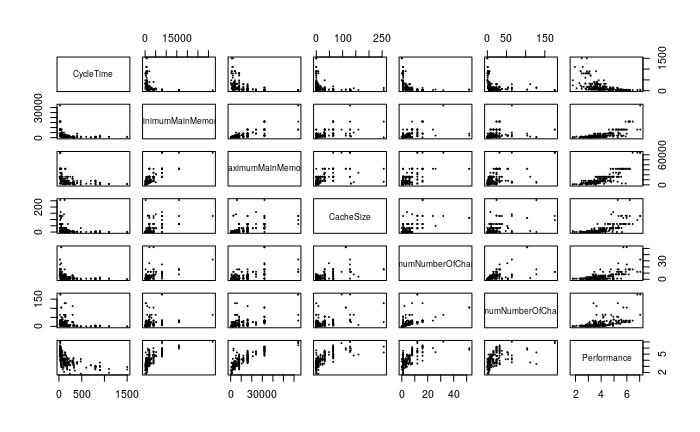

```r
cpu_LogY <- cpu
cpu_LogY$Performance <- log(cpu_LogY$Performance)
pairs(cpu_LogY, cex = 0.1)
```

Following tis transformation it appears as if all variables follow a $\sqrt{x}$ distribution and cycle time is hyperbolic

```r
cpu.logY.lm <- lm(I(log(Performance)) ~ ., data = cpu)
cpu_log
```

| CycleTime | MinimumMainMemory | MaximumMainMemory | CacheSize | MinimumNumberOfChannels | MaximumNumberOfChannels | Performance |
| --- | --- | --- | --- | --- | --- | --- |
| 4.836282 | 5.549076 | 8.699681 | 5.5490761 | 2.8332133 | 4.8598124 | 5.293305 |
| 3.401197 | 8.987322 | 10.373522 | 3.4965076 | 2.1972246 | 3.4965076 | 5.598422 |
| 3.401197 | 8.987322 | 10.373522 | 3.4965076 | 2.1972246 | 3.4965076 | 5.398163 |
| 3.401197 | 8.987322 | 10.373522 | 3.4965076 | 2.1972246 | 3.4965076 | 5.153292 |
| 3.401197 | 8.987322 | 9.680406 | 3.4965076 | 2.1972246 | 2.8332133 | 4.890349 |
| 3.295837 | 8.987322 | 10.373522 | 4.1743873 | 2.1972246 | 3.4965076 | 5.765191 |
| 3.178054 | 9.680406 | 10.373522 | 4.1743873 | 2.8332133 | 3.4965076 | 5.908083 |
| 3.178054 | 9.680406 | 10.373522 | 4.1743873 | 2.8332133 | 3.4965076 | 6.194405 |
| 3.178054 | 9.680406 | 11.066654 | 4.1743873 | 2.8332133 | 3.4965076 | 6.456770 |
| 3.178054 | 10.373522 | 11.066654 | 4.8598124 | 3.4965076 | 4.1743873 | 7.043160 |

[output cut: 199 more lines]

```r
summary(cpu.loglm)
```

[output not shown]

[figure not shown]

[figure not shown]

[figure not shown]

[figure not shown]

```r
plot(cpu.loglm)
```

```r
AIC(cpu.loglm)
```

[output not shown]

```r
BIC(cpu.loglm)
```

[output not shown]

similar AIC/BIC, similar R^2, similar RSE so we accpet only a log transform of performance, probably non-linear relations on the other data are described by something other than being a log (e.g. Cycle really looks hyperbolic)

the residuals are all more or less normal at this stage so we will leave it at that and worry about polynomials in a bit.

#### Fit a model and use backwards selection

#### Consider interactions

Use a tree to look at interactions

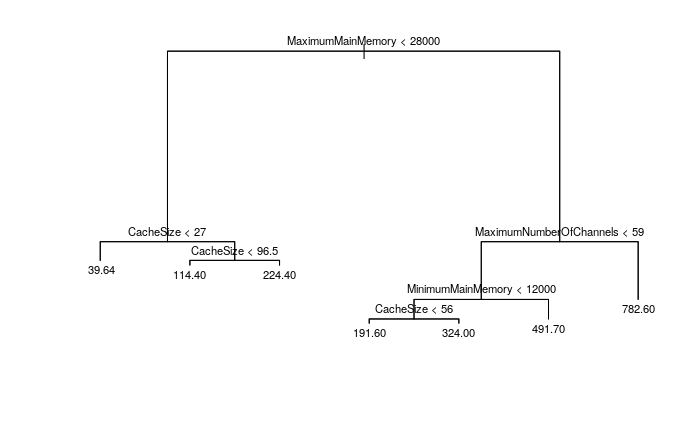

```r
cpu.tree <- tree(Performance ~ ., data = cpu)
plot(cpu.tree)
text(cpu.tree, pretty = 1, cex = 0.7)
```

This demonstrates that Main Memory is the biggest predictor of the CPU Performance, if the main memory is high then the number of channels is influential, it is not influential otherwise, so perhaps there is interaction between these two terms.

Cache Size seems influential only low max memory or high max memory but lowMinMemory, however low min memory implies low max memory, so perhaps cache size has a greater effecct when main memory is low, let’s try .

We’ll use the maximums because that’s what tree suggests and they haven’t been included in the model as features yet anyway.

Well include two way and three way interaction and use backwards selection to prune the model.

Remember that backwards selection must be one at a time

```r
cpu.loglm <- lm(formula = I(log(Performance)) ~ . +I(MaximumMainMemory * MaximumNumberOfChannels) + I(CacheSize * MaximumMainMemory) + I(CacheSize * MaximumMainMemory * MaximumNumberOfChannels), data = cpu)
summary(cpu.loglm)
```

```
Call:
lm(formula = I(log(Performance)) ~ . + I(MaximumMainMemory *
    MaximumNumberOfChannels) + I(CacheSize * MaximumMainMemory) +
    I(CacheSize * MaximumMainMemory * MaximumNumberOfChannels),
    data = cpu)

Residuals:
     Min       1Q   Median       3Q      Max
-1.39049 -0.24860  0.03242  0.24303  1.09405

Coefficients:
                                                             Estimate Std. Error t value Pr(>|t|)
(Intercept)                                                 3.117e+00  7.606e-02  40.978  < 2e-16 ***
CycleTime                                                  -5.913e-04  1.283e-04  -4.608 7.25e-06 ***
MinimumMainMemory                                           6.178e-05  1.455e-05   4.244 3.36e-05 ***
MaximumMainMemory                                           5.932e-05  7.106e-06   8.348 1.16e-14 ***
CacheSize                                                   1.356e-02  1.463e-03   9.267  < 2e-16 ***
MinimumNumberOfChannels                                     1.029e-02  6.126e-03   1.680   0.0945 .
MaximumNumberOfChannels                                     5.221e-04  2.409e-03   0.217   0.8287
I(MaximumMainMemory * MaximumNumberOfChannels)              3.746e-09  1.739e-07   0.022   0.9828
I(CacheSize * MaximumMainMemory)                           -4.701e-07  8.344e-08  -5.635 5.94e-08 ***
I(CacheSize * MaximumMainMemory * MaximumNumberOfChannels)  7.902e-10  1.329e-09   0.595   0.5528
---
Signif. codes:  0 ‘***’ 0.001 ‘**’ 0.01 ‘*’ 0.05 ‘.’ 0.1 ‘ ’ 1

Residual standard error: 0.418 on 199 degrees of freedom
Multiple R-squared:  0.8479,    Adjusted R-squared:  0.841
F-statistic: 123.3 on 9 and 199 DF,  p-value: < 2.2e-16
```

```r
#plot(cpu.loglm)

AIC(cpu.loglm)
```

```
[1] 240.231
```

```r
BIC(cpu.loglm)
```

```
[1] 276.9967
```

```r
cpu.loglm <- lm(formula = I(log(Performance)) ~ . +I(MaximumMainMemory * MaximumNumberOfChannels) + I(CacheSize * MaximumMainMemory * MaximumNumberOfChannels), data = cpu)
summary(cpu.loglm)
```

```
Call:
lm(formula = I(log(Performance)) ~ . + I(MaximumMainMemory *
    MaximumNumberOfChannels) + I(CacheSize * MaximumMainMemory *
    MaximumNumberOfChannels), data = cpu)

Residuals:
     Min       1Q   Median       3Q      Max
-1.46787 -0.25644  0.02411  0.26705  1.23078

Coefficients:
                                                             Estimate Std. Error t value Pr(>|t|)
(Intercept)                                                 3.296e+00  7.421e-02  44.411  < 2e-16 ***
CycleTime                                                  -7.402e-04  1.349e-04  -5.488 1.22e-07 ***
MinimumMainMemory                                           2.599e-05  1.407e-05   1.848   0.0661 .
MaximumMainMemory                                           4.555e-05  7.167e-06   6.355 1.38e-09 ***
CacheSize                                                   8.604e-03  1.256e-03   6.850 8.88e-11 ***
MinimumNumberOfChannels                                     5.495e-03  6.516e-03   0.843   0.4001
MaximumNumberOfChannels                                     2.628e-03  2.556e-03   1.028   0.3051
I(MaximumMainMemory * MaximumNumberOfChannels)              1.495e-07  1.847e-07   0.810   0.4190
I(CacheSize * MaximumMainMemory * MaximumNumberOfChannels) -2.300e-09  1.300e-09  -1.769   0.0785 .
---
Signif. codes:  0 ‘***’ 0.001 ‘**’ 0.01 ‘*’ 0.05 ‘.’ 0.1 ‘ ’ 1

Residual standard error: 0.449 on 200 degrees of freedom
Multiple R-squared:  0.8237,    Adjusted R-squared:  0.8166
F-statistic: 116.8 on 8 and 200 DF,  p-value: < 2.2e-16
```

```r
AIC(cpu.loglm)
```

```
[1] 269.1686
```

```r
BIC(cpu.loglm)
```

```
[1] 302.592
```

The Memory Channel Interaction is the next one to go:

```r
cpu.loglm <- lm(formula = I(log(Performance)) ~ .  + I(CacheSize * MaximumMainMemory * MaximumNumberOfChannels), data = cpu)
summary(cpu.loglm)
```

```
Call:
lm(formula = I(log(Performance)) ~ . + I(CacheSize * MaximumMainMemory *
    MaximumNumberOfChannels), data = cpu)

Residuals:
     Min       1Q   Median       3Q      Max
-1.45051 -0.25789  0.02285  0.27304  1.29649

Coefficients:
                                                             Estimate Std. Error t value Pr(>|t|)
(Intercept)                                                 3.276e+00  6.994e-02  46.835  < 2e-16 ***
CycleTime                                                  -7.330e-04  1.345e-04  -5.451 1.46e-07 ***
MinimumMainMemory                                           2.346e-05  1.370e-05   1.712 0.088467 .
MaximumMainMemory                                           4.953e-05  5.209e-06   9.509  < 2e-16 ***
CacheSize                                                   8.045e-03  1.048e-03   7.674 7.07e-13 ***
MinimumNumberOfChannels                                     4.653e-03  6.428e-03   0.724 0.469943
MaximumNumberOfChannels                                     3.936e-03  1.980e-03   1.988 0.048125 *
I(CacheSize * MaximumMainMemory * MaximumNumberOfChannels) -1.294e-09  3.827e-10  -3.381 0.000869 ***
---
Signif. codes:  0 ‘***’ 0.001 ‘**’ 0.01 ‘*’ 0.05 ‘.’ 0.1 ‘ ’ 1

Residual standard error: 0.4486 on 201 degrees of freedom
Multiple R-squared:  0.8231,    Adjusted R-squared:  0.8169
F-statistic: 133.6 on 7 and 201 DF,  p-value: < 2.2e-16
```

```r
AIC(cpu.loglm)
```

```
[1] 267.8527
```

```r
BIC(cpu.loglm)
```

```
[1] 297.9337
```

```r
cpu.loglm <- lm(formula = I(log(Performance)) ~ . -MinimumMainMemory + I(CacheSize * MaximumMainMemory * MaximumNumberOfChannels), data = cpu)
summary(cpu.loglm)
```

```
Call:
lm(formula = I(log(Performance)) ~ . - MinimumMainMemory + I(CacheSize *
    MaximumMainMemory * MaximumNumberOfChannels), data = cpu)

Residuals:
     Min       1Q   Median       3Q      Max
-1.44339 -0.27496  0.02305  0.27053  1.25300

Coefficients:
                                                             Estimate Std. Error t value Pr(>|t|)
(Intercept)                                                 3.274e+00  7.027e-02  46.590  < 2e-16 ***
CycleTime                                                  -7.397e-04  1.351e-04  -5.477 1.28e-07 ***
MaximumMainMemory                                           5.527e-05  4.008e-06  13.788  < 2e-16 ***
CacheSize                                                   8.494e-03  1.020e-03   8.329 1.23e-14 ***
MinimumNumberOfChannels                                     6.694e-03  6.346e-03   1.055 0.292778
MaximumNumberOfChannels                                     3.049e-03  1.920e-03   1.588 0.113768
I(CacheSize * MaximumMainMemory * MaximumNumberOfChannels) -1.345e-09  3.833e-10  -3.509 0.000555 ***
---
Signif. codes:  0 ‘***’ 0.001 ‘**’ 0.01 ‘*’ 0.05 ‘.’ 0.1 ‘ ’ 1

Residual standard error: 0.4507 on 202 degrees of freedom
Multiple R-squared:  0.8205,    Adjusted R-squared:  0.8152
F-statistic: 153.9 on 6 and 202 DF,  p-value: < 2.2e-16
```

```r
AIC(cpu.loglm)
```

```
[1] 268.8778
```

```r
BIC(cpu.loglm)
```

```
[1] 295.6164
```

It looks like the three way interaction is going to stay, so we’ll make that its own column so we can use simple residual plots:

```r
cpuBS <- cpu
cpuBS$interact <- cpu$CacheSize*cpu$MaximumMainMemory*cpu$MaximumNumberOfChannels
cpuBS$Performance <- log(cpu$Performance)
```

The minimum number of channels is the next least significant because it is so well predicted by Manimum number of channels

```r
cpu.loglm <- lm(formula = Performance ~ . -MinimumNumberOfChannels -MinimumMainMemory + interact, data = cpuBS)
summary(cpu.loglm)
```

```
Call:
lm(formula = Performance ~ . - MinimumNumberOfChannels - MinimumMainMemory +
    interact, data = cpuBS)

Residuals:
     Min       1Q   Median       3Q      Max
-1.44209 -0.25307  0.01739  0.27313  1.26943

Coefficients:
                          Estimate Std. Error t value Pr(>|t|)
(Intercept)              3.274e+00  7.028e-02  46.588  < 2e-16 ***
CycleTime               -7.439e-04  1.350e-04  -5.509 1.08e-07 ***
MaximumMainMemory        5.639e-05  3.865e-06  14.592  < 2e-16 ***
CacheSize                8.851e-03  9.624e-04   9.197  < 2e-16 ***
MaximumNumberOfChannels  3.633e-03  1.839e-03   1.976 0.049562 *
interact                -1.390e-09  3.810e-10  -3.649 0.000335 ***
---
Signif. codes:  0 ‘***’ 0.001 ‘**’ 0.01 ‘*’ 0.05 ‘.’ 0.1 ‘ ’ 1

Residual standard error: 0.4508 on 203 degrees of freedom
Multiple R-squared:  0.8195,    Adjusted R-squared:  0.8151
F-statistic: 184.3 on 5 and 203 DF,  p-value: < 2.2e-16
```

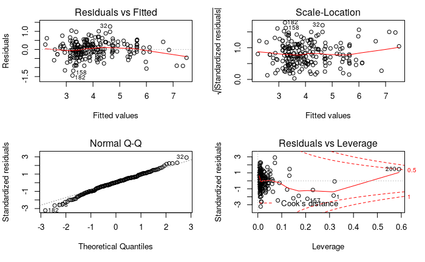

```r
layout(matrix(1:4, nrow = 2))
plot(cpu.loglm)
```

```r
AIC(cpu.loglm)
```

```
[1] 268.0258
```

```r
BIC(cpu.loglm)
```

```
[1] 291.4221
```

All terms are now significant and the residuals are sufficiently normal and so the model is accepted as sufficient:

# Question 02

Consider “CPU_Performance.csv” dataset to answer the following questions.

The cycle time is the period, the inverse of which is the frequency, we may expect cpu requency to be proportional to performance and the data appears hyperbolic, so we choose a hyperbolic model for CPU performance.

## 1. Select the most suitable attribute of CPU that can be used to predict accurately the performance of CPU using Polynomial Regression. Justify your choice of the attribute.

## 2. Use 10-fold cross-validation to select the optimal polynomial regression model.

## 3. Comment on the accuracy of the model.

## 4. Carry out model diagnostics and comment your findings.

# Question 03

Consider “Wine_Quality.csv” dataset to answer the following questions.

## 1. Divide the dataset into Training set with 4000 observations and assign rest of the observations into Test set. [Use set.seed as 10 to generate same randomness.]

## 2. Build a decision tree model to predict the Quality of Wine. Hence, identify the attributes that contribute in creating a Quality Wine.

## 3. Comment on the performance of the model obtained.

## 4. Manufacturer classifies the wine quality as high if WineQuality > 6 and low otherwise. Create a new variable to categorise it as high or low and name it “Wine_Cat”. Build a decision tree model to classify the Quality of Wine.

[^1]: [Handling Multicollinearity in Regression Analysis](https://blog.minitab.com/blog/understanding-statistics/handling-multicollinearity-in-regression-analysis)
[^2]: [Implications of Log Transform](https://www.ncbi.nlm.nih.gov/pmc/articles/PMC4120293/)
[^3]: [stathowto](https://www.statisticshowto.datasciencecentral.com/probability-and-statistics/skewed-distribution/)
[^4]: [A post on Discuss Analytics](https://discuss.analyticsvidhya.com/t/methods-to-deal-with-zero-values-while-performing-log-transformation-of-variable/2431/5)
[^5]: [abline is the problem when its called inside qq plot](https://stackoverflow.com/questions/40572124/plot-lm-error-operator-is-invalid-for-atomic-vectors)